# Road Traffic Accidents Exploratory Data Analysis

Group 7

2023-01-20

### Group Members

S2155520 || Hossein Golmohammadi

S2108177 || Rahman karimiyazdi

S2162214 || Yang Wang

S2150932 || Amirah Nur Binti Azman

S2163882 || Yaping Wang

# Introduction

Driving is the most dangerous thing most Americans do every day. Virtually every American knows someone who’s been injured in a car crash, and each year cars kill about as many people as guns and severely injure millions. Cars killed 42,060 people in 2020, up from 39,107 in 2019, according to a preliminary estimate from the National Safety Council (NSC). An accident dataset was analyzed in order to provide a better understanding of this problem.

# Objectives

This project we will analyze it mainly using R to determine the main causes of accidents, which is a classification task to achieve road traffic accident classification. In general, the project has two objectives:

Severity of Traffic Accidents Data Analysis

To predict Severity traffic accidents

# Data Pre-Proccessing

## Load the Dataset

First, the data was uploaded by the read.csv command in order to access the data. This dataset has 12,316 records or (rows) and 15 features (columns).

```r
    data <- read.csv("traffic_Accident.csv",header =T,na.strings=c(""))
    head(data,3)
```

```
#>   Age_Categories Sex_of_driver  Educational_level Vehicle_driver_relation
#> 1          18-30          Male  Above high school                Employee
#> 2          31-50          Male Junior high school                Employee
#> 3          18-30          Male Junior high school                Employee
#>   Driving_experience  Lanes_or_Medians Types_of_Junction Road_surface_type
#> 1              1-2yr              <NA>       No junction     Asphalt roads
#> 2         Above 10yr Undivided Two way       No junction     Asphalt roads
#> 3              1-2yr             other       No junction     Asphalt roads
#>   Light_conditions Weather_conditions                       Type_of_collision
#> 1         Daylight             Normal Collision with roadside-parked vehicles
#> 2         Daylight             Normal          Vehicle with vehicle collision
#> 3         Daylight             Normal         Collision with roadside objects
#>   Vehicle_movement Pedestrian_movement         Cause_of_accident
#> 1   Going straight    Not a Pedestrian           Moving Backward
#> 2   Going straight    Not a Pedestrian                Overtaking
#> 3   Going straight    Not a Pedestrian Changing lane to the left
#>   Accident_severity
#> 1                NA
#> 2                NA
#> 3                 1
```

```r
    dim(data)
```

```
#> [1] 12316    15
```

## Summary of the Dataset

Summary is a generic function used to produce result summaries, including the number of records, unique categories, mean, standard deviation, min, max and quartiles of the dataset.

```r
summary(data)
```

```
#>  Age_Categories     Sex_of_driver      Educational_level
#>  Length:12316       Length:12316       Length:12316
#>  Class :character   Class :character   Class :character
#>  Mode  :character   Mode  :character   Mode  :character
#>
#>
#>
#>
#>  Vehicle_driver_relation Driving_experience Lanes_or_Medians
#>  Length:12316            Length:12316       Length:12316
#>  Class :character        Class :character   Class :character
#>  Mode  :character        Mode  :character   Mode  :character
#>
#>
#>
#>
#>  Types_of_Junction  Road_surface_type  Light_conditions   Weather_conditions
#>  Length:12316       Length:12316       Length:12316       Length:12316
#>  Class :character   Class :character   Class :character   Class :character
#>  Mode  :character   Mode  :character   Mode  :character   Mode  :character
#>
#>
#>
#>
#>  Type_of_collision  Vehicle_movement   Pedestrian_movement Cause_of_accident
#>  Length:12316       Length:12316       Length:12316        Length:12316
#>  Class :character   Class :character   Class :character    Class :character
#>  Mode  :character   Mode  :character   Mode  :character    Mode  :character
#>
#>
#>
#>
#>  Accident_severity
#>  Min.   :0.000
#>  1st Qu.:2.000
#>  Median :2.000
#>  Mean   :1.833
#>  3rd Qu.:2.000
#>  Max.   :2.000
#>  NA's   :13
```

## Identifying the columns with missing values

The is.na function shows the number of nulls per column.

```r
colSums(is.na(data)==TRUE|data=='')
```

```
#>          Age_Categories           Sex_of_driver       Educational_level
#>                    1548                     178                     841
#> Vehicle_driver_relation      Driving_experience        Lanes_or_Medians
#>                     593                     862                     442
#>       Types_of_Junction       Road_surface_type        Light_conditions
#>                    1078                     172                       0
#>      Weather_conditions       Type_of_collision        Vehicle_movement
#>                     292                     169                     396
#>     Pedestrian_movement       Cause_of_accident       Accident_severity
#>                       0                      25                      13
```

## The Number of Missing Values

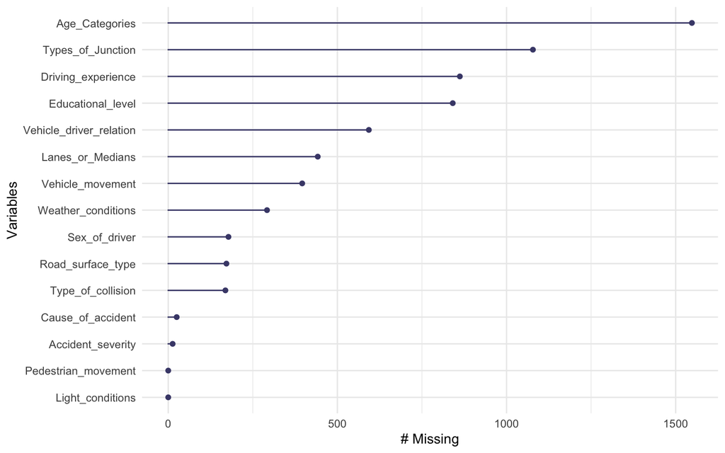

```r
gg_miss_var(data)
```

## The Precentage of missing values

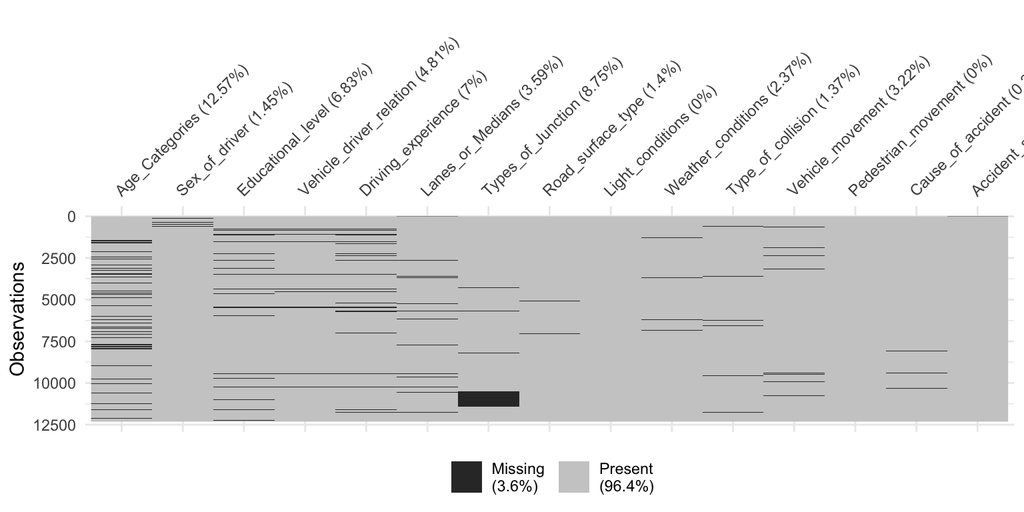

```r
vis_miss(data)
```

## Impute Data

The missing data can create problems for analyzing data. Replacing missing data with substituted values is seen as a way to avoid pitfalls involved with listwise deletion of cases that have missing values. In the “Accident_Severity” column. The null values were replaced by the mean of the feature.

```r
data$Accident_severity[is.na(data$Accident_severity)==TRUE] = round(mean(data$Accident_severity, na.rm = TRUE))
```

The null values in the four other columns including “Age_Categories”, “Educational_level”, “Driving_experience”, “Lanes_or_Medians”, “Educational_level”, “Driving_experience”, “Lanes_or_Medians” were replaced with the mode of the feature as shown in below respectively.

```r
getmode <- function(a) {
  uniqage <- unique(a)
  uniqage[which.max(tabulate(match(a, uniqage)))]
}

data$Age_Categories[is.na(data$Age_Categories)==TRUE]= getmode(data$Age_Categories)
print( getmode(data$Age_Categories))
```

```
#> [1] "18-30"
```

```r
data$Educational_level[is.na(data$Educational_level)==TRUE]= getmode(data$Educational_level)
print( getmode(data$Educational_level))
```

```
#> [1] "Junior high school"
```

```r
data$Driving_experience[is.na(data$Driving_experience)==TRUE] = getmode(data$Driving_experience)
print(getmode(data$Driving_experience))
```

```
#> [1] "5-10yr"
```

```r
data$Lanes_or_Medians[is.na(data$Lanes_or_Medians)==TRUE] = getmode(data$Lanes_or_Medians)
print(getmode(data$Lanes_or_Medians))
```

```
#> [1] "Two-way (divided with broken lines road marking)"
```

The missing values in other columns including, “Road_surface_type”, “Type_of_collision”, “Cause_of_accident”, “Types_of_Junction”, “Vehicle_movement”, “Vehicle_driver_relation”, “Weather_conditions”, “Sex_of_driver” were replaced by the “Unknown” keyword because of the importance and high sensitivity of the columns’ values in the analysis stage and obviously making a better decision based on them.

```r
data$Road_surface_type[is.na(data$Road_surface_type)==TRUE]= "Unknown"

data$Type_of_collision[is.na(data$Type_of_collision)==TRUE]= "Unknown"

data$Cause_of_accident[is.na(data$Cause_of_accident)==TRUE]= "Unknown"

data$Types_of_Junction [is.na(data$Types_of_Junction )==TRUE]= "Unknown"

data$Vehicle_movement[is.na(data$Vehicle_movement)==TRUE]= "Unknown"

data$Vehicle_driver_relation[is.na(data$Vehicle_driver_relation)==TRUE]= "Unknown"

data$Weather_conditions[is.na(data$Weather_conditions)==TRUE]= "Unknown"

data$Sex_of_driver[is.na(data$Sex_of_driver)==TRUE]= "Unknown"
```

After imputation the dataset, the vis_miss function was run to recheck the null data situation. Fortunately, There was no missing data anymore.

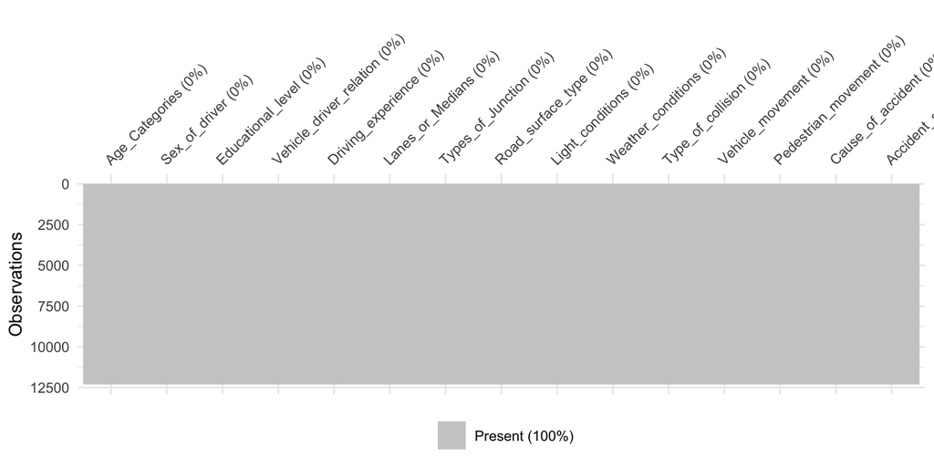

```r
vis_miss(data)
```

```r
colSums(is.na(data)==TRUE|data=='')
```

```
#>          Age_Categories           Sex_of_driver       Educational_level
#>                       0                       0                       0
#> Vehicle_driver_relation      Driving_experience        Lanes_or_Medians
#>                       0                       0                       0
#>       Types_of_Junction       Road_surface_type        Light_conditions
#>                       0                       0                       0
#>      Weather_conditions       Type_of_collision        Vehicle_movement
#>                       0                       0                       0
#>     Pedestrian_movement       Cause_of_accident       Accident_severity
#>                       0                       0                       0
```

# Data Analysis

## Accident Severity and Type of Collision

The diagram below shows the number of accidents in every level of severity and every level categorized by the number of collision types. The highest level of severity accounts for most of the accidents with vehicle collisions.

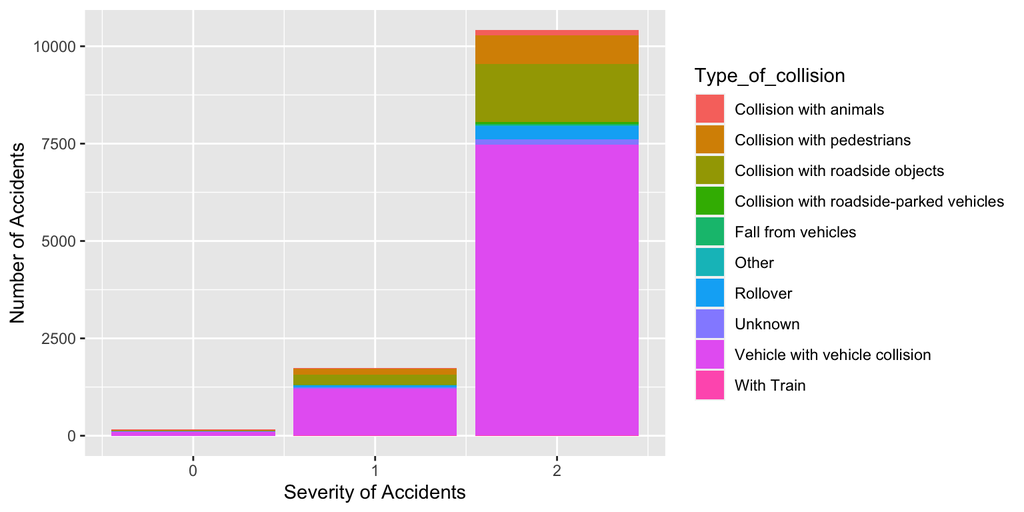

```r
 ggplot(data) +
      geom_bar(aes(x = Accident_severity, fill = Type_of_collision)) +
      xlab("Severity of Accidents") + ylab("Number of Accidents")
```

## Causes of Accident

There are plenty of causes for an accident to take place. The highest cause for an accident is “No Distance” with a total of 2,250 accidents. This indicated that accidents happened due to no safe distance between vehicles when on the road.

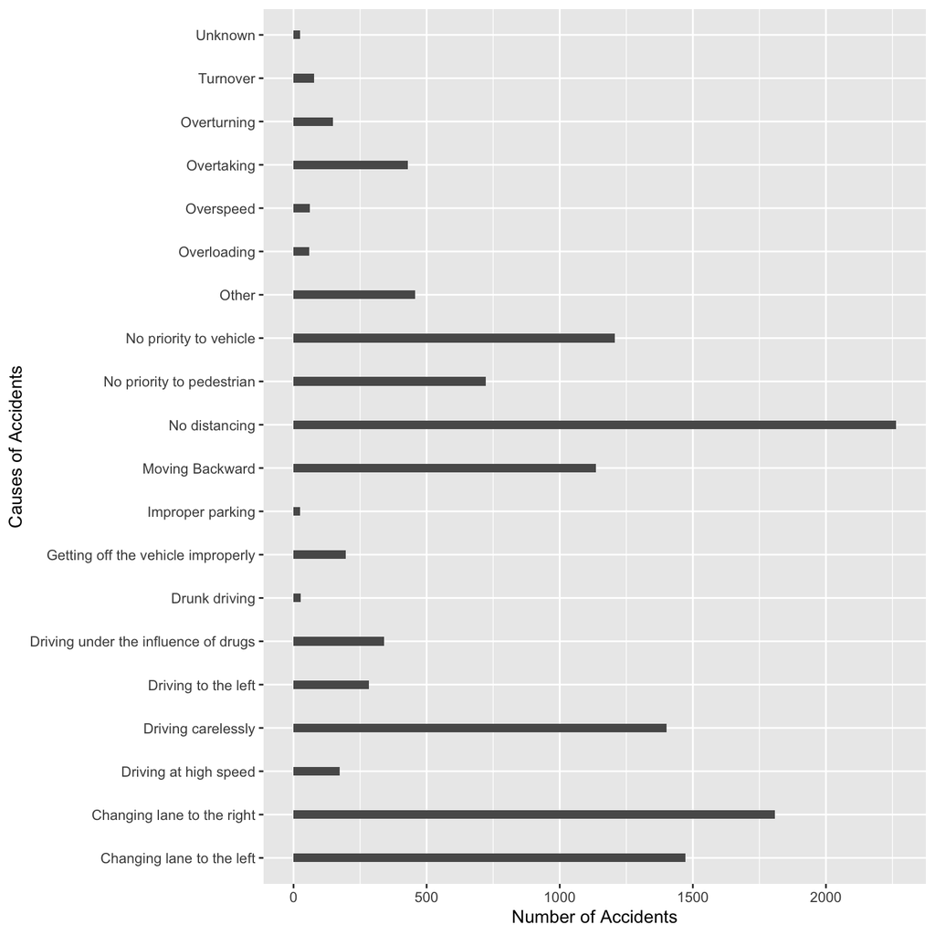

```r
p_causes <- ggplot(data) +
      geom_bar(aes(x = Cause_of_accident), position = "dodge", width = 0.2) +
      xlab("Causes of Accidents") + ylab("Number of Accidents")
p_causes + coord_flip()
```

## Accident Severity and Gender

In both female and male gender, the majority of accident occur in the highest level of severity.

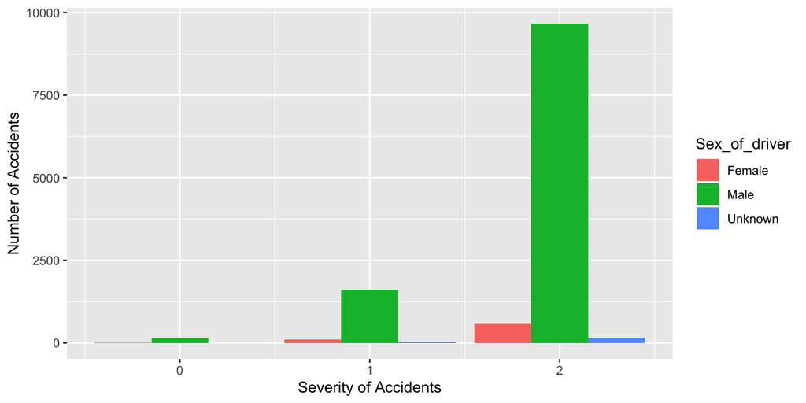

```r
 ggplot(data, aes(x=Accident_severity, fill=Sex_of_driver )) +
      geom_bar(position = "dodge") +
      labs(x="Severity of Accidents",y="Number of Accidents")
```

## Accident Severity and Age

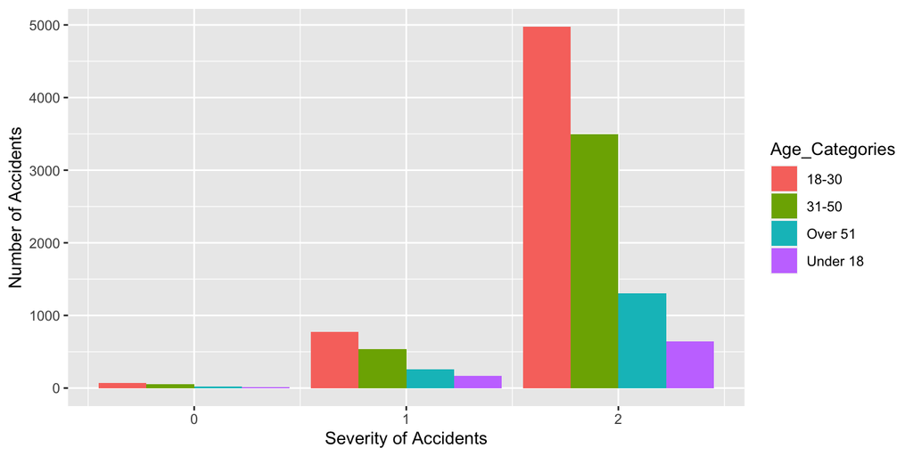

```r
 ggplot(data, aes(x=Accident_severity, fill=Age_Categories )) +
      geom_bar(position = "dodge") +
      labs(x="Severity of Accidents",y="Number of Accidents")
```

## Accident Severity and Experience

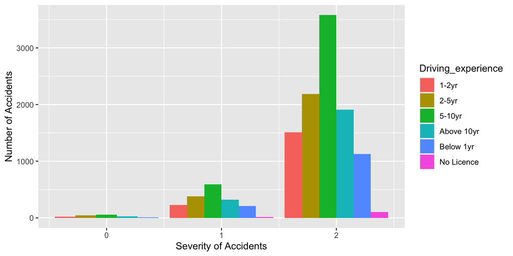

```r
 ggplot(data, aes(x=Accident_severity, fill=Driving_experience )) +
      geom_bar(position = "dodge") +
      labs(x="Severity of Accidents",y="Number of Accidents")
```

## Accident Severity and Junction

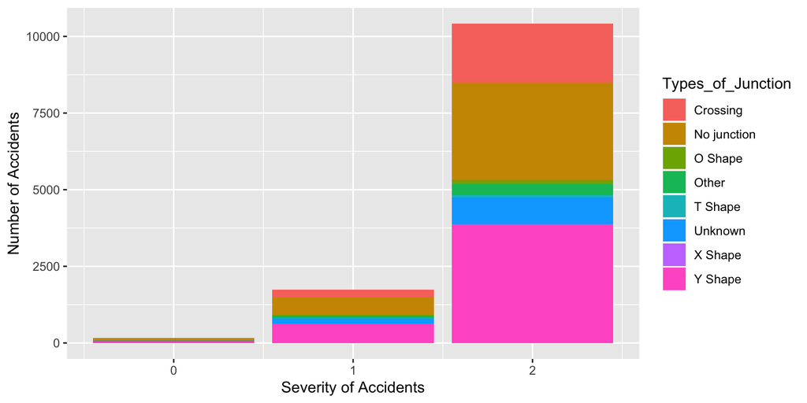

```r
 ggplot(data) +
      geom_bar(aes(x = Accident_severity, fill = Types_of_Junction)) +
      xlab("Severity of Accidents") + ylab("Number of Accidents")
```

## Weather Conditions

As the diagram shows, the vast majority of accidents occur in normal weather. It seems weather conditions do not play an important role in the occurrence of accidents.

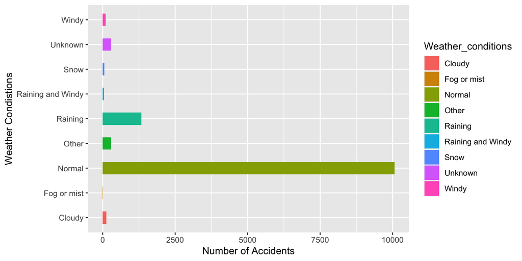

```r
p_weather <- ggplot(data) +
      geom_bar(aes(x =Weather_conditions , fill = Weather_conditions), width = 0.5) +
      xlab("Weather Condistions") + ylab("Number of Accidents")
p_weather + coord_flip()
```

## Type of Roads

The number of accidents that happen on Asphalt roads are dramatically higher than other types of road. It seems the type of roads do not play an important role in the occurrence of accidents.

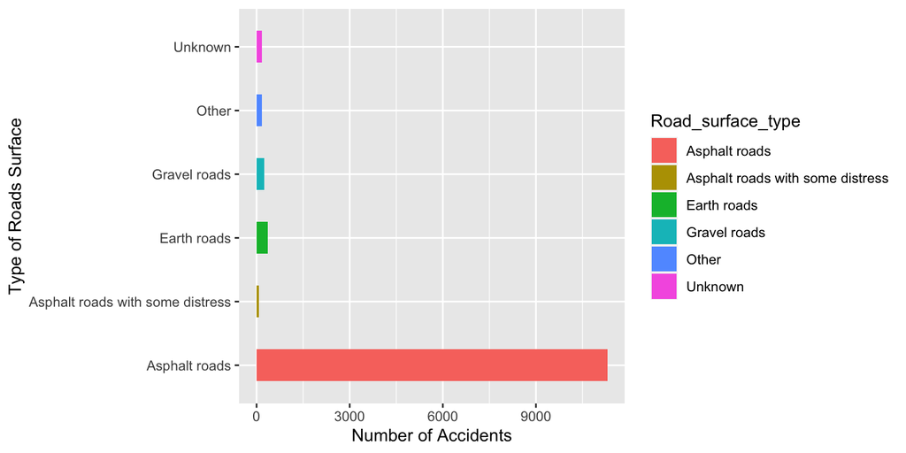

```r
p_road <- ggplot(data) +
      geom_bar(aes(x = Road_surface_type, fill=Road_surface_type), position = "dodge", width = 0.5) +
      xlab("Type of Roads Surface") + ylab("Number of Accidents")
p_road + coord_flip()
```

## Accident Severity and Light Conditions

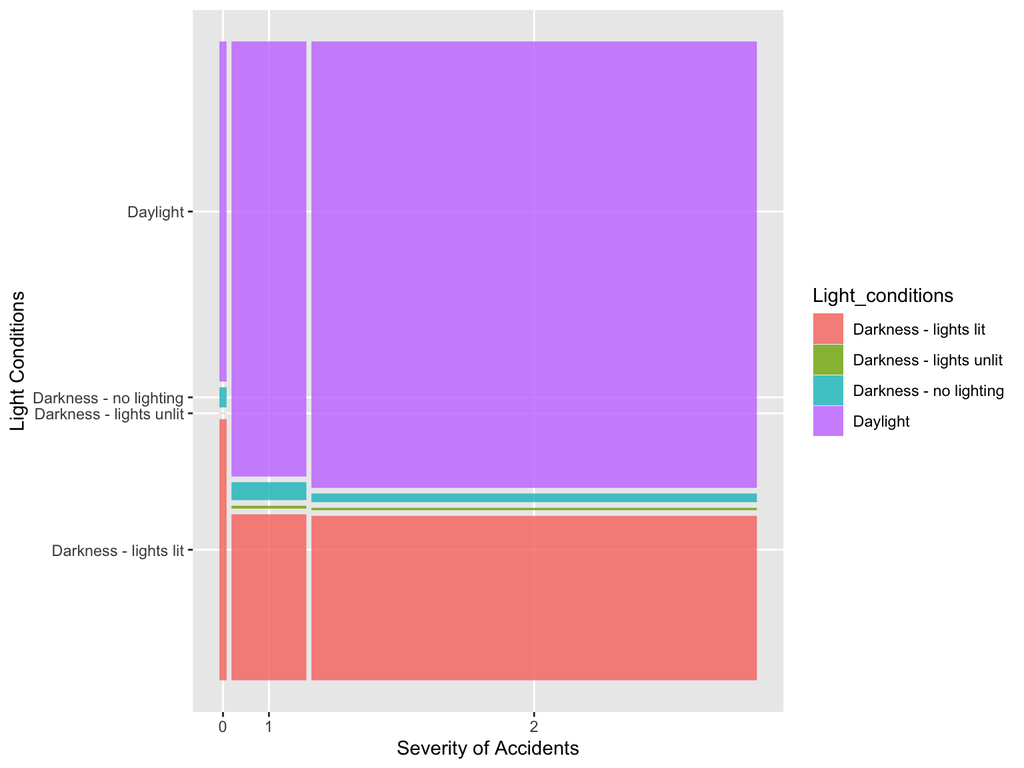

```r
 ggplot(data) + geom_mosaic(aes(x = product(Light_conditions, Accident_severity), fill = Light_conditions)) +
      xlab("Severity of Accidents") + ylab("Light Conditions")
```

# Machine Learning

Machine learning is about learning to predict something or extracting knowledge from data. ML algorithms build a model based on sample data or known as training data and based upon the training data the algorithm can predict something on new data. The central goal of this section is to design a model that makes proper accident severity classifications for new accidents. In the first step, it was essential to change the “Accident_severity” type to factor in order the ML algorithm can be run.

```r
data$Accident_severity <- as.factor(data$Accident_severity)
str(data)
```

```
#> 'data.frame':    12316 obs. of  15 variables:
#>  $ Age_Categories         : chr  "18-30" "31-50" "18-30" "18-30" ...
#>  $ Sex_of_driver          : chr  "Male" "Male" "Male" "Male" ...
#>  $ Educational_level      : chr  "Above high school" "Junior high school" "Junior high school" "Junior high school" ...
#>  $ Vehicle_driver_relation: chr  "Employee" "Employee" "Employee" "Employee" ...
#>  $ Driving_experience     : chr  "1-2yr" "Above 10yr" "1-2yr" "5-10yr" ...
#>  $ Lanes_or_Medians       : chr  "Two-way (divided with broken lines road marking)" "Undivided Two way" "other" "other" ...
#>  $ Types_of_Junction      : chr  "No junction" "No junction" "No junction" "Y Shape" ...
#>  $ Road_surface_type      : chr  "Asphalt roads" "Asphalt roads" "Asphalt roads" "Earth roads" ...
#>  $ Light_conditions       : chr  "Daylight" "Daylight" "Daylight" "Darkness - lights lit" ...
#>  $ Weather_conditions     : chr  "Normal" "Normal" "Normal" "Normal" ...
#>  $ Type_of_collision      : chr  "Collision with roadside-parked vehicles" "Vehicle with vehicle collision" "Collision with roadside objects" "Vehicle with vehicle collision" ...
#>  $ Vehicle_movement       : chr  "Going straight" "Going straight" "Going straight" "Going straight" ...
#>  $ Pedestrian_movement    : chr  "Not a Pedestrian" "Not a Pedestrian" "Not a Pedestrian" "Not a Pedestrian" ...
#>  $ Cause_of_accident      : chr  "Moving Backward" "Overtaking" "Changing lane to the left" "Changing lane to the right" ...
#>  $ Accident_severity      : Factor w/ 3 levels "0","1","2": 3 3 2 3 3 3 3 3 3 2 ...
```

## Random Forest

The first ML model is Random Forest. It builds and combines multiple decision trees to get more accurate predictions. It’s a non-linear classification algorithm. They are called random because they choose predictors randomly at a time of training. They are called forest because they take the output of multiple trees to make a decision. Random forest outperforms decision trees as a large number of uncorrelated trees(models) operating as a committee will always outperform the individual constituent models. In the below the function is created to run the Random Forest.

```r
RF<-function(s, df, col) {
  trainIndex<-createDataPartition(col, p=s, list=F)
  data_train<-df[trainIndex,]
  data_test<-df[-trainIndex,]
  model <- randomForest(Accident_severity~., data=data_train)

  # make predictions
  x_test <- data_test[,1:14]
  y_test <- data_test[,15]
  predictions <- predict(model, x_test)
  cm<-confusionMatrix(predictions, y_test)
  return(cm)
}
```

## Train & Test Split

The data splitted to 70% and 30% for train and test respectively and then the results are shown. The model has 84% Accuracy.

```r
split<-0.70  # 70%/30% train/test
result4<-RF(split, data, data$Accident_severity)

result4
```

```
#> Confusion Matrix and Statistics
#>
#>           Reference
#> Prediction    0    1    2
#>          0    0    0    0
#>          1    0    2    4
#>          2   47  520 3121
#>
#> Overall Statistics
#>
#>                Accuracy : 0.8454
#>                  95% CI : (0.8334, 0.8569)
#>     No Information Rate : 0.846
#>     P-Value [Acc > NIR] : 0.5474
#>
#>                   Kappa : 0.0039
#>
#>  Mcnemar's Test P-Value : NA
#>
#> Statistics by Class:
#>
#>                      Class: 0  Class: 1 Class: 2
#> Sensitivity           0.00000 0.0038314 0.998720
#> Specificity           1.00000 0.9987390 0.003515
#> Pos Pred Value            NaN 0.3333333 0.846258
#> Neg Pred Value        0.98728 0.8590022 0.333333
#> Prevalence            0.01272 0.1413102 0.845966
#> Detection Rate        0.00000 0.0005414 0.844884
#> Detection Prevalence  0.00000 0.0016243 0.998376
#> Balanced Accuracy     0.50000 0.5012852 0.501117
```

## k-Fold

Cross-validation is a resampling procedure used to evaluate machine learning models on a limited data sample. The procedure has a single parameter called k that refers to the number of groups that a given data sample is to be split into. The data split it into 5 groups (k = 5). mtry is the number of variables to randomly sample as candidates at each split. As it shows the most accurate value for mtry was 2 with an accuracy of 84%.

```r
train_control <- trainControl(method="cv", number=5)
modelRF <- train(Accident_severity~., data=data, trControl=train_control, method="rf")
modelRF
```

```
#> Random Forest
#>
#> 12316 samples
#>    14 predictor
#>     3 classes: '0', '1', '2'
#>
#> No pre-processing
#> Resampling: Cross-Validated (5 fold)
#> Summary of sample sizes: 9851, 9852, 9854, 9853, 9854
#> Resampling results across tuning parameters:
#>
#>   mtry  Accuracy   Kappa
#>    2    0.8458105  0.0000000000
#>   48    0.8305471  0.0008341889
#>   94    0.8267311  0.0045876709
#>
#> Accuracy was used to select the optimal model using the largest value.
#> The final value used for the model was mtry = 2.
```

## KNN

```r
KNN<-function(s, df, col) {
  trainIndex<-createDataPartition(col, p=s, list=F)
  data_train<-df[trainIndex,]
  data_test<-df[-trainIndex,]
  model <- train(Accident_severity~., data=data_train, method = "knn")

  # make predictions
  x_test <- data_test[,1:14]
  y_test <- data_test[,15]
  predictions <- predict(model, x_test)
  cm<-confusionMatrix(predictions, y_test)
  return(list(model, cm))
}
```

## Train & Test Split

```r
split<-0.70  # 70%/30% train/test
result6<-KNN(split, data, data$Accident_severity)


result6
```

```
#> [[1]]
#> k-Nearest Neighbors
#>
#> 8622 samples
#>   14 predictor
#>    3 classes: '0', '1', '2'
#>
#> No pre-processing
#> Resampling: Bootstrapped (25 reps)
#> Summary of sample sizes: 8622, 8622, 8622, 8622, 8622, 8622, ...
#> Resampling results across tuning parameters:
#>
#>   k  Accuracy   Kappa
#>   5  0.8206729   0.0004635365
#>   7  0.8318231  -0.0004889696
#>   9  0.8379111   0.0011986709
#>
#> Accuracy was used to select the optimal model using the largest value.
#> The final value used for the model was k = 9.
#>
#> [[2]]
#> Confusion Matrix and Statistics
#>
#>           Reference
#> Prediction    0    1    2
#>          0    0    0    0
#>          1    0    1    1
#>          2   47  521 3124
#>
#> Overall Statistics
#>
#>                Accuracy : 0.846
#>                  95% CI : (0.8339, 0.8575)
#>     No Information Rate : 0.846
#>     P-Value [Acc > NIR] : 0.5112
#>
#>                   Kappa : 0.0025
#>
#>  Mcnemar's Test P-Value : NA
#>
#> Statistics by Class:
#>
#>                      Class: 0  Class: 1 Class: 2
#> Sensitivity           0.00000 0.0019157 0.999680
#> Specificity           1.00000 0.9996847 0.001757
#> Pos Pred Value            NaN 0.5000000 0.846154
#> Neg Pred Value        0.98728 0.8588841 0.500000
#> Prevalence            0.01272 0.1413102 0.845966
#> Detection Rate        0.00000 0.0002707 0.845696
#> Detection Prevalence  0.00000 0.0005414 0.999459
#> Balanced Accuracy     0.50000 0.5008002 0.500719
```

## K-Fold

The data split it into 5 groups (k = 5). As it shows the most accurate value for mtry was 9 with an accuracy of 84.5%.

```r
train_control <- trainControl(method="cv", number=5)
modelknn <- train(Accident_severity~., data=data, trControl=train_control, method="knn")
modelknn
```

```
#> k-Nearest Neighbors
#>
#> 12316 samples
#>    14 predictor
#>     3 classes: '0', '1', '2'
#>
#> No pre-processing
#> Resampling: Cross-Validated (5 fold)
#> Summary of sample sizes: 9852, 9853, 9852, 9853, 9854
#> Resampling results across tuning parameters:
#>
#>   k  Accuracy   Kappa
#>   5  0.8409383  -0.0004069517
#>   7  0.8440241  -0.0026536194
#>   9  0.8450796  -0.0013954312
#>
#> Accuracy was used to select the optimal model using the largest value.
#> The final value used for the model was k = 9.
```

# Conclusion